# Gender Differences in Language Input to Children

Mika Braginsky and Stephan Meylan

2016-05-12

## Get word counts

Load files with CHILDES word count data, as outputted by `get_childes_counts.py`.

```r
files <- list.files("data", full.names = TRUE, recursive = TRUE)
nltk_counts <- map_df(files, function(file) {
  file_parts <- file %>% gsub(".csv", "", .) %>% strsplit("/") %>% unlist()
  doc <- read.csv(file, stringsAsFactors = FALSE) %>%
    mutate(filename = paste(file_parts[2:length(file_parts)], collapse = "/"),
           count = as.numeric(count))
  return(doc)
}) %>%
  rename(gloss = word, nltk_count = count)
```

Load CHILDES metadata and manually coded gender data for files that are missing gender information, join them to word count data, and sum word counts per word and gender.

```r
metadata <- read_csv("metadata.csv")
coded_sex <- read_csv("missing_sex.csv") %>%
  rename(coded_sex = sex)

gender_counts <- nltk_counts %>%
  left_join(metadata) %>%
  left_join(coded_sex) %>%
  mutate(gender = ifelse(sex != "None", sex, coded_sex)) %>%
  filter(!is.na(gender)) %>%
  group_by(gender, gloss) %>%
  summarise(count = sum(nltk_count))
```

## Get CDI data

Load English WS and WG datasets from Wordbank.

```r
eng_ws <- get_instrument_data(instrument_language = "English",
                              instrument_form = "WS",
                              administrations = TRUE,
                              iteminfo = TRUE,
                              mode = mode)

eng_wg <- get_instrument_data(instrument_language = "English",
                              instrument_form = "WG",
                              administrations = TRUE,
                              iteminfo = TRUE,
                              mode = mode)
```

For each dataset, compute proportion of children of each age and gender who produce/understand each word, fit a logistic regression to those proportions, and then estimate the area between the curves for girls and boys.

```r
fit_gender_diffs <- function(dataset, form_name, save_plots = FALSE) {

  gender_props <- dataset %>%
    filter(!is.na(sex), type == "word") %>%
    mutate(produces = value == "produces",
           understands = (value == "produces" | value == "understands"),
           definition = gsub("\\*", "", definition)) %>%
    select(-value) %>%
    gather(measure, value, understands, produces) %>%
    group_by(measure, sex, age, lexical_class, category, definition) %>%
    summarise(num_true = sum(value, na.rm = TRUE),
              num_false = n() - num_true,
              prop = num_true / n()) %>%
    filter(form_name == "WG" | measure == "produces")

  width <- 0.1
  fit_group <- function(group_data) {
    model <- glm(cbind(num_true, num_false) ~ age, family = "binomial",
                 data = group_data)
    ages <- seq(min(group_data$age), max(group_data$age), by = width)
    fits <- model %>%
      predict(newdata = data.frame(age = ages)) %>%
      boot::inv.logit()
    data_frame(age = ages, fit = fits)
  }

  compute_area <- function(group_fits) {
    data_frame(area = sum(group_fits$fit * width))
  }

  gender_fits <- gender_props %>%
    group_by(measure, sex, lexical_class, category, definition) %>%
    nest() %>%
    mutate(fits = map(data, fit_group))

  # word_gender_diffs <- gender_fits %>%
  #   select(-data) %>%
  #   unnest() %>%
  #   spread(sex, fit) %>%
  #   mutate(gender_diff = Female - Male) %>%
  #   group_by(definition) %>%
  #   mutate(threshold_diff = max(abs(gender_diff)) > 0.16) %>%
  #   filter(definition != "penis")

  # ggplot(word_gender_diffs, aes(x = age, y = gender_diff, group = definition,
  #                               colour = lexical_class)) +
  #   facet_wrap(~category) +
  #   geom_hline(yintercept = 0, colour = "grey", linetype = "dashed") +
  #   geom_line(colour = "grey", alpha = 0.5,
  #             data = word_gender_diffs %>% filter(!threshold_diff)) +
  #   geom_line(data = word_gender_diffs %>% filter(threshold_diff)) +
  #   geom_dl(aes(label = definition),
  #           method = list("last.points", dl.trans(x = x + 0.1),
  #                         cex = 0.5, fontfamily = font),
  #           data = word_gender_diffs %>%
  #             filter(age == max(age), threshold_diff)) +
  #   scale_colour_solarized(guide = FALSE) +
  #   xlim(c(min(word_gender_diffs$age), max(word_gender_diffs$age) + 3))

  if (save_plots) {
    gender_fits %>%
      select(-data) %>%
      unnest() %>%
      split(paste(.$measure, .$definition)) %>%
      walk(function(plt_data) {
        dir <- paste(form_name, plt_data$measure[[1]], sep = "_")
        filename <- gsub("[ \\/]", "_", plt_data$definition[[1]])
        plt <- ggplot(plt_data, aes(x = age, y = fit, colour = sex)) +
          facet_wrap(~definition) +
          geom_line() +
          scale_colour_solarized(name = "") +
          ylim(c(0, 1)) +
          labs(x = "Age (months)", y = "Proportion of children") +
          theme(legend.key = element_blank())
        ggsave(sprintf("item_plots/%s/%s.png", dir, filename),
               plt, width = 6, height = 4)
      })
  }

  gender_areas <- gender_fits %>%
    mutate(area = map(fits, compute_area)) %>%
    select(-data, -fits) %>%
    unnest()

  gender_areas %>%
    spread(sex, area) %>%
    rename(female_area = Female, male_area = Male) %>%
    mutate(area_diff = female_area - male_area,
           form = form_name,
           form_measure = paste(form, measure, sep = "_"))

}

gender_diffs_wg <- fit_gender_diffs(eng_wg, "WG")
gender_diffs_ws <- fit_gender_diffs(eng_ws, "WS")

gender_diffs <- bind_rows(gender_diffs_wg, gender_diffs_ws)
```

To estimate the reliability of area differences, split datasets into groups and find the correlation between the groups’ area difference estimates.

```r
random_group <- function(n, probs) {
  g <- findInterval(seq(0, 1, length = n), c(0, cumsum(probs)),
                    rightmost.closed = TRUE)
  names(probs)[sample(g)]
}

fit_gender_diffs_groups <- function(dataset, form_name, n_groups = 2) {

  group_probs <- setNames(rep(1 / n_groups, n_groups),
                          paste0("group", 1:n_groups))

  groups <- dataset %>%
    select(data_id) %>%
    unique() %>%
    mutate(group = random_group(n(), group_probs))

  dataset_grouped <- dataset %>%
    left_join(groups)

  group_fits <- dataset_grouped %>%
    split(.$group) %>%
    map(~fit_gender_diffs(.x, form_name))

  joined_groups <- group_fits %>%
    reduce(~left_join(.x, .y,
                      by = c("measure", "lexical_class", "definition")))

  joined_groups %>%
    group_by(measure) %>%
    nest() %>%
    mutate(cor = map_dbl(data, ~cor(.x$area_diff.y, .x$area_diff.x)),
           reliability = n_groups * cor / (1 + (n_groups - 1) * cor)) %>%
    select(-data)

}

gender_diffs_wg_groups <- fit_gender_diffs_groups(eng_wg, "WG")
gender_diffs_ws_groups <- fit_gender_diffs_groups(eng_ws, "WS")

gender_diffs_groups <- bind_rows(gender_diffs_wg_groups,
                                 gender_diffs_ws_groups)

knitr::kable(gender_diffs_groups)
```

| measure | cor | reliability |
| --- | --- | --- |
| produces | 0.7435582 | 0.8529204 |
| understands | 0.7847348 | 0.8793853 |
| produces | 0.8663949 | 0.9284154 |

Plot distribution of acquisition differences for each measure and lexical category.

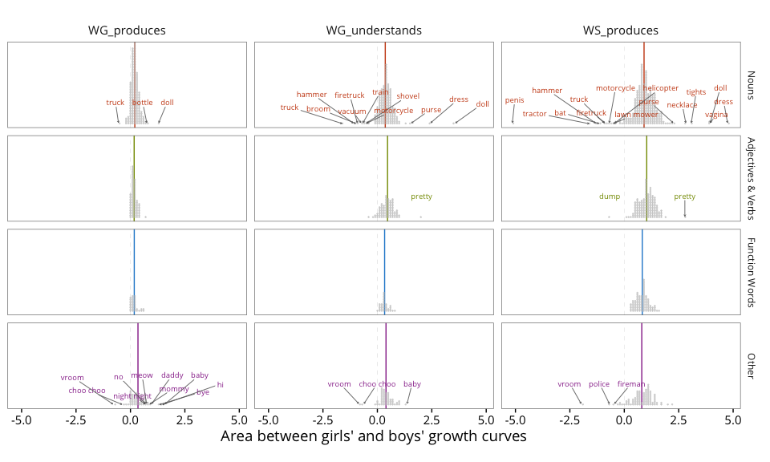

```r
threshold <- 0.99
lexical_classes <- list("Nouns" = "nouns",
                        "Adjectives & Verbs" = c("adjectives", "verbs"),
                        "Function Words" = "function_words",
                        "Other" = "other")

plt_gender_diffs <- gender_diffs %>%
  # group_by(form_measure, lexical_class) %>%
  group_by(form_measure) %>%
  mutate(label = gsub("(.*) \\(.*\\)", "\\1", definition),
         area_diff_scaled = as.numeric(scale(area_diff)),
         outlier = pnorm(abs(area_diff_scaled)) > threshold) %>%
  ungroup() %>%
  mutate(lexical_class = `levels<-`(factor(lexical_class), lexical_classes))

gender_diff_means <- plt_gender_diffs %>%
  group_by(form_measure, lexical_class) %>%
  summarise(mean_area_diff = mean(area_diff))

binwidth <- 0.1
ggplot(plt_gender_diffs, aes(x = area_diff, colour = lexical_class)) +
  coord_fixed(ratio = 2 * binwidth, ylim = c(0, 18)) +
  # facet_grid(form_measure ~ lexical_class) +
  facet_grid(lexical_class ~ form_measure) +
  geom_vline(xintercept = 0, linetype = "dashed", colour = "grey",
             size = 0.1) +
  geom_vline(aes(xintercept = mean_area_diff, colour = lexical_class),
             size = 0.5,
             #alpha = 0.5,
             data = filter(gender_diff_means)) +
  geom_dotplot(#aes(fill = lexical_class),
    method = "histodot", fill = "grey", colour = "grey", alpha = 0.5,
    binwidth = binwidth, dotsize = 0.5, stackratio = 1.5) +
  geom_text_repel(aes(label = label, y = 0),
                  data = filter(plt_gender_diffs, outlier),
                  segment.size = 0.3, point.padding = unit(0.2, "lines"),
                  arrow = arrow(length = unit(0.02, "npc")), nudge_y = 5,
                  family = font, size = 2.5) +
  scale_colour_solarized(guide = FALSE) +
  scale_fill_solarized(guide = FALSE) +
  scale_y_continuous(NULL, breaks = NULL) +
  labs(x = "Area between girls' and boys' growth curves") +
  theme(strip.text.y = element_text(size = 9))
```

## Combine word count data with CDI data

Build up a mapping between CDI items and possible words for them in CHILDES.

```r
stem <- function(x) SnowballC::wordStem(x) %>% gsub("'", "", .)

special_cases <- read_csv("english_special_cases.csv", col_names = FALSE)

transforms <- c(
  function(x) gsub("(.*) \\(.*\\)", "\\1", x),
  function(x) gsub(" ", "_", x),
  function(x) gsub(" ", "+", x),
  function(x) gsub("(.+) \\1", "\\1", x)
)

special_case_map <- map_df(1:nrow(special_cases), function(i) {
  item <- special_cases$X1[i]
  options <- special_cases[i, 2:ncol(special_cases)] %>%
    as.character() %>%
    discard(is.na)
  trans_opts <- map(options, function(opt) map_chr(transforms, ~.x(opt))) %>%
    unlist() %>% unique()
  data_frame(item = rep(item, 2 * length(trans_opts)),
             gloss = c(trans_opts, stem(trans_opts)))
})

pattern_map <- gender_diffs$definition %>%
  unique() %>%
  map_df(function(item) {
    options <- item %>% strsplit("/") %>% unlist()
    options <- c(options, stem(options))
    trans_opts <- map(options, function(opt) map_chr(transforms, ~.x(opt))) %>%
      unlist() %>% unique()
    data_frame(item = rep(item, 2 * length(trans_opts)),
               gloss = c(trans_opts, stem(trans_opts))) %>%
      distinct()
  })

case_map <- bind_rows(special_case_map, pattern_map) %>% distinct()
```

Sum word counts over CDI items.

```r
item_gender_counts <- gender_counts %>%
  mutate(gloss = gsub("-.*", "", gloss),
         gloss = ifelse(stem(gloss) == "", gloss, stem(gloss))) %>%
  left_join(case_map) %>%
  mutate(item = ifelse(is.na(item), gloss, item)) %>%
  group_by(gender, item) %>%
  summarise(count = sum(count)) %>%
  spread(gender, count, fill = 0) %>%
  filter(female != 0, male != 0)
```

Compute various metrics of item frequency differences.

```r
gsq <- function(female, male) {
  a <- female
  b <- male
  c <- sum(female)
  d <- sum(male)
  e_1 <- c * (a + b) / (c + d)
  e_2 <- d * (a + b) / (c + d)
  2 * (a * log(a / e_1) + b * log(b / e_2))
}


mut_inf <- function(female, male) {
  log2(female / sum(female) * (sum(female) + sum(male)) / (female + male))
}

kl <- function(female, male) {
  p <- female / sum(female)
  q <- male / sum(male)
  p * log(p / q)
}

item_gender_data <- item_gender_counts %>%
  mutate(mut_inf = mut_inf(female, male),
         gsq = gsq(female, male),
         kl = kl(female, male)) %>%
  rename(female_count = female, male_count = male)
```

Combine acquistion differences with frequency differences

```r
min_count <- 30
gender_diff_freqs <- plt_gender_diffs %>%
  rename(item = definition) %>%
  inner_join(item_gender_data) %>%
  mutate(log_female_prob = log(female_count / sum(female_count)),
         log_male_prob = log(male_count / sum(male_count)),
         log_prob = log((female_count + male_count) /
                          (sum(female_count) + sum(male_count)))) %>%
  filter(female_count > min_count, male_count > min_count)
```

Plot frequency to boys against frequency to girls.

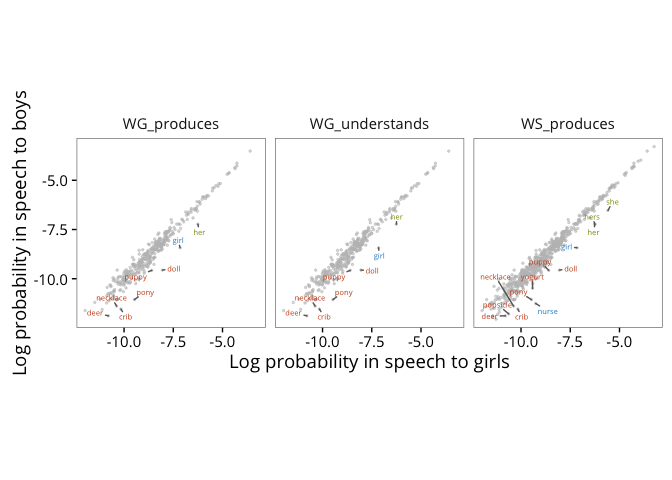

```r
ggplot(gender_diff_freqs, aes(x = log_female_prob, y = log_male_prob)) +
  facet_wrap(~form_measure) +
  coord_fixed() +
  geom_point(colour = "grey", alpha = 0.5, size = 0.5) +
  geom_text_repel(aes(label = item, colour = lexical_class), family = font,
                  size = 2,
                  data = gender_diff_freqs %>%
                    filter(mut_inf > 0.5)) +
#                    filter(abs(log_female_prob - log_male_prob) > 1)) +
#                    filter(outlier)) +
  scale_colour_solarized(guide = FALSE) +
  labs(x = "Log probability in speech to girls",
       y = "Log probability in speech to boys")
```

Predict acquisition differences from frequency differences.

```r
predictor <- "mut_inf"
predictor_formula <- as.formula(sprintf("area_diff ~ %s", predictor))

gender_diff_lexcat_models <- gender_diff_freqs %>%
  group_by(form_measure, lexical_class) %>%
  nest() %>%
  mutate(model = data %>%
           map(~lm(predictor_formula, data = .)),
         results = model %>% map(~broom::tidy(.x) %>%
                                   mutate(rsq = summary(.x)$r.squared))) %>%
  select(form_measure, lexical_class, results) %>%
  unnest()

knitr::kable(gender_diff_lexcat_models)
```

| form_measure | lexical_class | term | estimate | std.error | statistic | p.value | rsq |
| --- | --- | --- | --- | --- | --- | --- | --- |
| WG_produces | Adjectives & Verbs | (Intercept) | 0.1773555 | 0.0140553 | 12.6184528 | 0.0000000 | 0.0380489 |
| WG_produces | Adjectives & Verbs | mut_inf | 0.1327712 | 0.0715730 | 1.8550449 | 0.0669768 | 0.0380489 |
| WG_produces | Function Words | (Intercept) | 0.1728131 | 0.0282555 | 6.1160792 | 0.0000006 | 0.0101993 |
| WG_produces | Function Words | mut_inf | -0.1365945 | 0.2307722 | -0.5919019 | 0.5578320 | 0.0101993 |
| WG_produces | Nouns | (Intercept) | 0.1833732 | 0.0142717 | 12.8487187 | 0.0000000 | 0.0790398 |
| WG_produces | Nouns | mut_inf | 0.2510868 | 0.0616940 | 4.0698756 | 0.0000685 | 0.0790398 |
| WG_produces | Other | (Intercept) | 0.3585256 | 0.0593005 | 6.0459074 | 0.0000002 | 0.0015677 |
| WG_produces | Other | mut_inf | 0.0741490 | 0.2729508 | 0.2716570 | 0.7870755 | 0.0015677 |
| WG_understands | Adjectives & Verbs | (Intercept) | 0.5048536 | 0.0333216 | 15.1509326 | 0.0000000 | 0.1404954 |
| WG_understands | Adjectives & Verbs | mut_inf | 0.6398873 | 0.1696824 | 3.7710873 | 0.0002957 | 0.1404954 |
| WG_understands | Function Words | (Intercept) | 0.3351245 | 0.0306058 | 10.9497129 | 0.0000000 | 0.0044568 |
| WG_understands | Function Words | mut_inf | 0.0975228 | 0.2499675 | 0.3901420 | 0.6988651 | 0.0044568 |
| WG_understands | Nouns | (Intercept) | 0.2894185 | 0.0314384 | 9.2058788 | 0.0000000 | 0.1829676 |
| WG_understands | Nouns | mut_inf | 0.8934573 | 0.1359026 | 6.5742486 | 0.0000000 | 0.1829676 |
| WG_understands | Other | (Intercept) | 0.4084666 | 0.0529129 | 7.7196007 | 0.0000000 | 0.0203498 |
| WG_understands | Other | mut_inf | 0.2406474 | 0.2435497 | 0.9880835 | 0.3281714 | 0.0203498 |
| WS_produces | Adjectives & Verbs | (Intercept) | 1.0526941 | 0.0303293 | 34.7087607 | 0.0000000 | 0.0942985 |
| WS_produces | Adjectives & Verbs | mut_inf | 0.6657173 | 0.1646570 | 4.0430552 | 0.0000825 | 0.0942985 |
| WS_produces | Function Words | (Intercept) | 0.8440685 | 0.0291175 | 28.9883446 | 0.0000000 | 0.0441050 |
| WS_produces | Function Words | mut_inf | 0.3694994 | 0.1764871 | 2.0936341 | 0.0389562 | 0.0441050 |
| WS_produces | Nouns | (Intercept) | 0.8576581 | 0.0350902 | 24.4415575 | 0.0000000 | 0.1893663 |
| WS_produces | Nouns | mut_inf | 1.1418824 | 0.1427273 | 8.0004482 | 0.0000000 | 0.1893663 |
| WS_produces | Other | (Intercept) | 0.8561020 | 0.0634063 | 13.5018470 | 0.0000000 | 0.0655000 |
| WS_produces | Other | mut_inf | 0.5897090 | 0.2555053 | 2.3080106 | 0.0237206 | 0.0655000 |

```r
gender_diff_models <- gender_diff_freqs %>%
  group_by(form_measure) %>%
  nest() %>%
  mutate(model = data %>% map(~lm(predictor_formula, data = .)),
         results = model %>% map(~broom::tidy(.x) %>%
                                   mutate(rsq = summary(.x)$r.squared))) %>%
  select(form_measure, results) %>%
  unnest()

knitr::kable(gender_diff_models)
```

| form_measure | term | estimate | std.error | statistic | p.value | rsq |
| --- | --- | --- | --- | --- | --- | --- |
| WG_produces | (Intercept) | 0.2082351 | 0.0118147 | 17.625090 | 0.000000 | 0.0283455 |
| WG_produces | mut_inf | 0.1816092 | 0.0555033 | 3.272042 | 0.001169 | 0.0283455 |
| WG_understands | (Intercept) | 0.3740423 | 0.0196839 | 19.002451 | 0.000000 | 0.1056277 |
| WG_understands | mut_inf | 0.6087938 | 0.0924714 | 6.583590 | 0.000000 | 0.1056277 |
| WS_produces | (Intercept) | 0.9175358 | 0.0199905 | 45.898620 | 0.000000 | 0.1227213 |
| WS_produces | mut_inf | 0.8380401 | 0.0908703 | 9.222381 | 0.000000 | 0.1227213 |

Plot acquisition differences against frequency differences by lexical class.

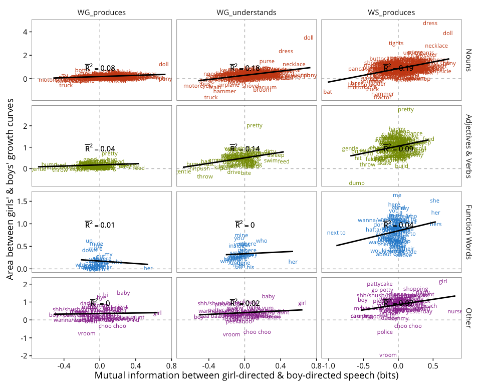

```r
ggplot(gender_diff_freqs, aes_string(x = predictor, y = "area_diff")) +
  facet_grid(lexical_class ~ form_measure, scales = "free") +
  geom_hline(yintercept = 0, linetype = "dashed", colour = "grey") +
  geom_vline(xintercept = 0, linetype = "dashed", colour = "grey") +
  geom_text(aes(label = label, colour = lexical_class), size = 3,
            family = font) +
  geom_smooth(colour = "black", method = "lm", se = FALSE) +
  geom_text(aes(label = sprintf("bar(R)^2==%.2f", rsq)), parse = TRUE,
            x = 0.004, y = 1, family = font,
            data = gender_diff_lexcat_models) +
  scale_colour_solarized(guide = FALSE) +
  ylab("Area between girls' & boys' growth curves") +
  xlab("Mutual information between girl-directed & boy-directed speech (bits)")
```

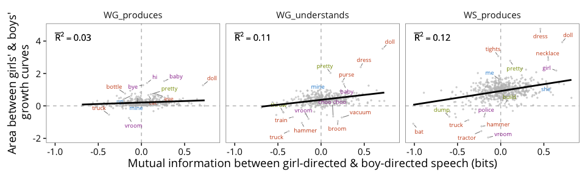

```r
ggplot(gender_diff_freqs, aes_string(x = predictor, y = "area_diff")) +
  facet_wrap(~form_measure) +
  geom_hline(yintercept = 0, linetype = "dashed", colour = "grey") +
  geom_vline(xintercept = 0, linetype = "dashed", colour = "grey") +
  geom_jitter(size = 0.5, colour = "grey", alpha = 0.5) +
  geom_text_repel(aes(label = label, colour = lexical_class),
                  data = filter(gender_diff_freqs, outlier),
                  segment.size = 0.3, point.padding = unit(0.2, "lines"),
                  family = font, size = 2.5) +
  geom_smooth(colour = "black", method = "lm", se = FALSE) +
  geom_text(aes(label = sprintf("bar(R)^2==%.2f", rsq)), parse = TRUE,
            x = -1, y = 4.3, hjust = "left", family = font,
            data = gender_diff_models) +
  scale_colour_solarized(guide = FALSE) +
  ylab("Area between girls' & boys'\n growth curves") +
  xlab("Mutual information between girl-directed & boy-directed speech (bits)")
```